# CEREO Workshop Day 2 R-Markdown

Jesse Burgher

Collaborator

11/17/2020

Abstract

This is an abstract. Practiving formatting here. Notes from the second day of the CEREO workshop focusing on R-Markdown Skills

It consists of two paragraphs how strange.

# Header One

Biggest header we can get with single pound sign.

## Header Two

Big

### Header Three

Medium

#### Header Four

Bold Small Header Line

Only need three hyphens to make line

Or underscore ___

Or Stars

# Intro to Markdown Syntax

### Text Formatting

Here is an example of **bold** text. Another example of **bold**. For italic text you use one *star*. Again you can use *underscores* as well. To use both bold and italics you can use *three* stars or *underscores* What about super scripts x<sup>2</sup>. And subscripts x<sub>2</sub> For underlining you need to use html underlined text underlined strike through = no!

### Line Breaks: To make lines show up there are a few things you can do.

Can add two spaces after line to add line break but not easy to see

Line 1  
Line 2

Line 1  
Line 2

* Note: that `<br>` doesn’t make a new paragraph it just does a line break.

### Body of the Document

This is our report introduction and we want to include supporting information in the form of a blockquote from and important person in our field.

> This is an important quote from an important source

> This person is *really* important

> > Can nest quotes within block quotes

Paragraph Two

Paragraph Three

### Lists

A numbered list

1. Item One
2. Item Two
3. Item Three

A Symbol list: Will always generate with bullet points

- Item One
- Item Two
- Item Three
- Item Four
- Item Five
- Item Six

A list with a sublist: This isn’t working for me

1. Item One i, subitem
2. Item Two ii. empty
3. Item Three

> This is my **super** important list
> 1. item 1
>    1. subitem
> 2. item 2
> 3. item 3

Paragraphs or descriptions under list items

1. Item 1

   This is a description for item one.
2. Item 2

   Second Paragrapoh desceription will be larger than listed item text.
3. Item 3

   Third decriptor paragraph, use two enters and two tabs for R MArkdown to recognise this as a paragraph.

### Tables in Markdown

| Col 1 | Col 2 | Col 3 | Col 4 |
| --- | --- | --- | --- |
| 1 | 0 | 1 | 0 |
| 0 | 1 | 0 | 1 |
| 0 | 1 | 1 | 0 |

Table 1: Demonstration of Messy Table

### Links and Graphics

Let’s say we want to include a **link** to another source of information. We can easily do tnat by including the links, http://rmarkdown.rstudio.com/lesson-1.html Or we can include hyperlinks with [link](http://rmarkdown.rstudio.com/lesson-1.html).

# Code Chunks in Markdown

Short cuts opt+Alt+i

```r
knitr::include_graphics("https://bookdown.org/yihui/rmarkdown/images/hex-rmarkdown.png")
```

[output not shown]

```r
x <- rnorm(n = 100,mean = 5, sd = 1)
```

```r
y <- 2 + 2*x + rnorm(n= length(x))
```

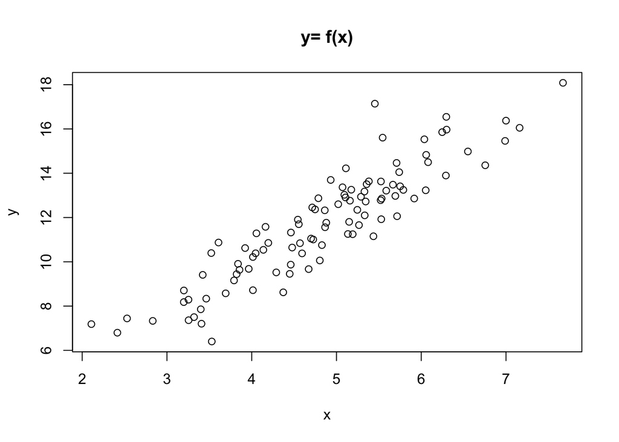

```r
plot(x,y, main = 'y= f(x)')
```

Include information between (x, y). Including math equations. This could be sueful to import into other processors as well!

Our response variable is $y$ is distributed $N(\mu, \sigma^2)$. where
$$\begin{align}
\mu &= 2 + 2*E[x] + E[e] \\[5pt]
\sigma^2 &= 2^2Var[x] + Var[e] + 2(2)Cov(x,e)
\end{align}$$

$$y=f(x)$$
We see that $\mu=$ 11.7276932 and $\sigma^2 =$ 6.5045783. Let’s round the outputs.

$\mu=$ 11.73

$\sigma^2 =$ 6.5

```r
df_all <- read_csv("data/daily_bike_data.csv")
dftemp <- df_all %>%
          select(cnt,temp)
```

```r
ss_dftemp <- sapply(dftemp,
                    function(x) c(mean(x), min(x), max(x), sd(x))) %>%
  data.frame()%>%
  round(digits = 2)

row.names(ss_dftemp) <- c('mean', 'min', 'max', 'sd')
ss_dftemp %>% knitr::kable(caption='Summary Statistics')
```

Summary Statistics

|  | cnt | temp |
| --- | --- | --- |
| mean | 4504.35 | 0.50 |
| min | 22.00 | 0.06 |
| max | 8714.00 | 0.86 |
| sd | 1937.21 | 0.18 |

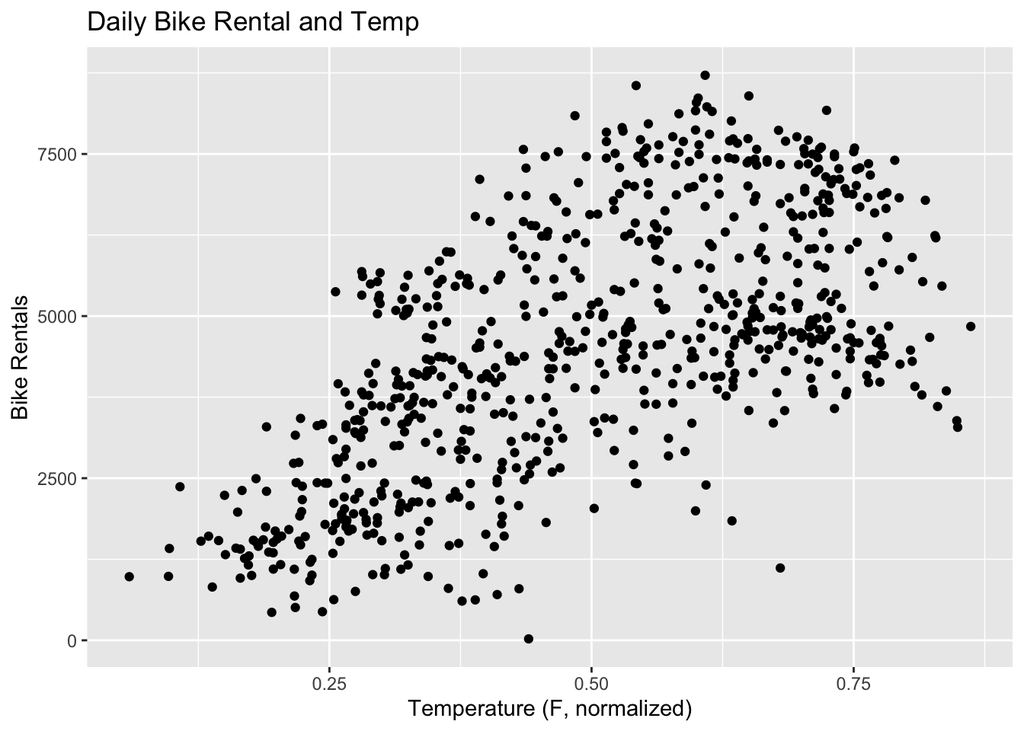

```r
ggplot(dftemp, aes(temp,cnt))+
  geom_point()+
  labs(title= 'Daily Bike Rental and Temp',
       x= 'Temperature (F, normalized)',
       y= 'Bike Rentals')
```

```r
dftemp <- dftemp %>%
  mutate(temp2 = temp^2)

mod1 <- lm(formula= cnt ~ temp,
           data = dftemp)

mod2 <- lm(formula = cnt ~ temp + temp2,
           data= dftemp)

pred_mod1 <- predict(mod1, dftemp['temp'])
pred_mod2 <- predict(mod2, dftemp[c('temp', 'temp2')])

dftemp <- dftemp %>%
  mutate(cnt_mod1= pred_mod1,
         cnt_mod2= pred_mod2)
```

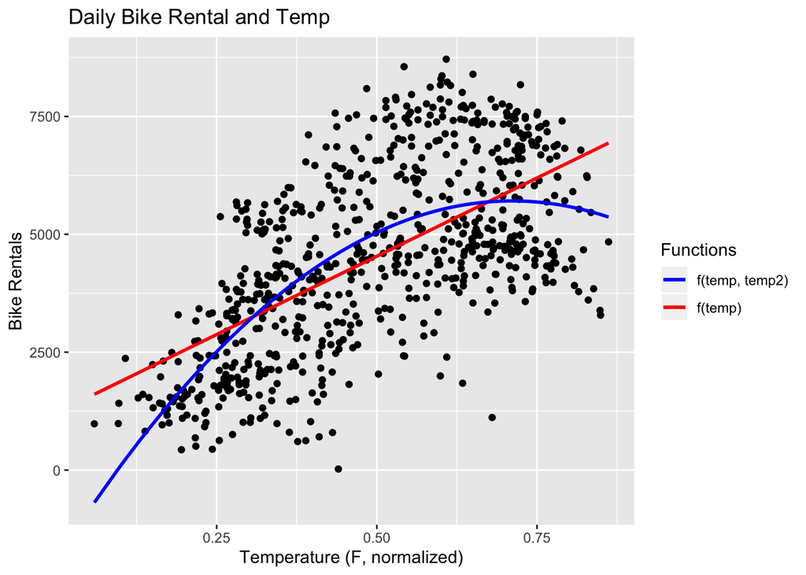

```r
ggplot(dftemp, aes(temp,cnt))+
  geom_point()+
  geom_line(aes(x=temp, y=pred_mod1, color = "f(temp)"), size = 1)+
  geom_line(aes(x=temp, y=pred_mod2,  color = "f(temp, temp2)"), size = 1)+
  labs(title= 'Daily Bike Rental and Temp',
       x= 'Temperature (F, normalized)',
       y= 'Bike Rentals',
       color = "Functions") +
  scale_color_manual(values = c('f(temp)'='red',
                                'f(temp, temp2)'= 'blue'))
```